# ECaluya_Assignment3_Q1

```python
import pandas as pd
import numpy as np
import matplotlib.pyplot as plt
%matplotlib inline

from sklearn.model_selection import KFold, train_test_split, cross_val_score, cross_validate
from sklearn.linear_model import LinearRegression, Lasso, Ridge, ElasticNet, SGDRegressor
from sklearn import feature_selection
from sklearn.preprocessing import StandardScaler
from sklearn.model_selection import GridSearchCV
```

```python
url = "communities/communities.csv"
comms = pd.read_csv(url)
comms.head(10)
```

|  | state | communityname | population | householdsize | racepctblack | racePctWhite | racePctAsian | racePctHisp | agePct12t21 | agePct12t29 | ... | NumStreet | PctForeignBorn | PctBornSameState | PctSameHouse85 | PctSameCity85 | PctSameState85 | LandArea | PopDens | PctUsePubTrans | ViolentCrimesPerPop |
| --- | --- | --- | --- | --- | --- | --- | --- | --- | --- | --- | --- | --- | --- | --- | --- | --- | --- | --- | --- | --- | --- |
| 0 | 8 | Lakewoodcity | 0.19 | 0.33 | 0.02 | 0.90 | 0.12 | 0.17 | 0.34 | 0.47 | ... | 0.0 | 0.12 | 0.42 | 0.50 | 0.51 | 0.64 | 0.12 | 0.26 | 0.20 | 0.20 |
| 1 | 53 | Tukwilacity | 0.00 | 0.16 | 0.12 | 0.74 | 0.45 | 0.07 | 0.26 | 0.59 | ... | 0.0 | 0.21 | 0.50 | 0.34 | 0.60 | 0.52 | 0.02 | 0.12 | 0.45 | 0.67 |
| 2 | 24 | Aberdeentown | 0.00 | 0.42 | 0.49 | 0.56 | 0.17 | 0.04 | 0.39 | 0.47 | ... | 0.0 | 0.14 | 0.49 | 0.54 | 0.67 | 0.56 | 0.01 | 0.21 | 0.02 | 0.43 |
| 3 | 34 | Willingborotownship | 0.04 | 0.77 | 1.00 | 0.08 | 0.12 | 0.10 | 0.51 | 0.50 | ... | 0.0 | 0.19 | 0.30 | 0.73 | 0.64 | 0.65 | 0.02 | 0.39 | 0.28 | 0.12 |
| 4 | 42 | Bethlehemtownship | 0.01 | 0.55 | 0.02 | 0.95 | 0.09 | 0.05 | 0.38 | 0.38 | ... | 0.0 | 0.11 | 0.72 | 0.64 | 0.61 | 0.53 | 0.04 | 0.09 | 0.02 | 0.03 |
| 5 | 6 | SouthPasadenacity | 0.02 | 0.28 | 0.06 | 0.54 | 1.00 | 0.25 | 0.31 | 0.48 | ... | 0.0 | 0.70 | 0.42 | 0.49 | 0.73 | 0.64 | 0.01 | 0.58 | 0.10 | 0.14 |
| 6 | 44 | Lincolntown | 0.01 | 0.39 | 0.00 | 0.98 | 0.06 | 0.02 | 0.30 | 0.37 | ... | 0.0 | 0.15 | 0.81 | 0.77 | 0.91 | 0.84 | 0.05 | 0.08 | 0.06 | 0.03 |
| 7 | 6 | Selmacity | 0.01 | 0.74 | 0.03 | 0.46 | 0.20 | 1.00 | 0.52 | 0.55 | ... | 0.0 | 0.59 | 0.58 | 0.52 | 0.79 | 0.78 | 0.01 | 0.33 | 0.00 | 0.55 |
| 8 | 21 | Hendersoncity | 0.03 | 0.34 | 0.20 | 0.84 | 0.02 | 0.00 | 0.38 | 0.45 | ... | 0.0 | 0.01 | 0.78 | 0.48 | 0.79 | 0.75 | 0.04 | 0.17 | 0.04 | 0.53 |
| 9 | 29 | Claytoncity | 0.01 | 0.40 | 0.06 | 0.87 | 0.30 | 0.03 | 0.90 | 0.82 | ... | 0.0 | 0.22 | 0.42 | 0.34 | 0.23 | 0.09 | 0.00 | 0.47 | 0.11 | 0.15 |

10 rows × 100 columns

A) Load and preprocess the data using Pandas or Numpy and, if necessary, preprocessing functions from scikit-learn. The provided data is already normalized (see description), so there is no need for additional normalization. Compute and display basic statistics (mean, standard deviation, min, max, etc.) for each of the variables in the data set. Separate the target attribute for regression.

```python
# displaying the basic statistics for the attributes
comms.describe()
```

|  | state | population | householdsize | racepctblack | racePctWhite | racePctAsian | racePctHisp | agePct12t21 | agePct12t29 | agePct16t24 | ... | NumStreet | PctForeignBorn | PctBornSameState | PctSameHouse85 | PctSameCity85 | PctSameState85 | LandArea | PopDens | PctUsePubTrans | ViolentCrimesPerPop |
| --- | --- | --- | --- | --- | --- | --- | --- | --- | --- | --- | --- | --- | --- | --- | --- | --- | --- | --- | --- | --- | --- |
| count | 1994.000000 | 1994.000000 | 1994.000000 | 1994.000000 | 1994.000000 | 1994.000000 | 1994.000000 | 1994.000000 | 1994.000000 | 1994.000000 | ... | 1994.000000 | 1994.000000 | 1994.000000 | 1994.000000 | 1994.000000 | 1994.000000 | 1994.000000 | 1994.000000 | 1994.000000 | 1994.000000 |
| mean | 28.683551 | 0.057593 | 0.463395 | 0.179629 | 0.753716 | 0.153681 | 0.144022 | 0.424218 | 0.493867 | 0.336264 | ... | 0.022778 | 0.215552 | 0.608892 | 0.535050 | 0.626424 | 0.651530 | 0.065231 | 0.232854 | 0.161685 | 0.237979 |
| std | 16.397553 | 0.126906 | 0.163717 | 0.253442 | 0.244039 | 0.208877 | 0.232492 | 0.155196 | 0.143564 | 0.166505 | ... | 0.100400 | 0.231134 | 0.204329 | 0.181352 | 0.200521 | 0.198221 | 0.109459 | 0.203092 | 0.229055 | 0.232985 |
| min | 1.000000 | 0.000000 | 0.000000 | 0.000000 | 0.000000 | 0.000000 | 0.000000 | 0.000000 | 0.000000 | 0.000000 | ... | 0.000000 | 0.000000 | 0.000000 | 0.000000 | 0.000000 | 0.000000 | 0.000000 | 0.000000 | 0.000000 | 0.000000 |
| 25% | 12.000000 | 0.010000 | 0.350000 | 0.020000 | 0.630000 | 0.040000 | 0.010000 | 0.340000 | 0.410000 | 0.250000 | ... | 0.000000 | 0.060000 | 0.470000 | 0.420000 | 0.520000 | 0.560000 | 0.020000 | 0.100000 | 0.020000 | 0.070000 |
| 50% | 34.000000 | 0.020000 | 0.440000 | 0.060000 | 0.850000 | 0.070000 | 0.040000 | 0.400000 | 0.480000 | 0.290000 | ... | 0.000000 | 0.130000 | 0.630000 | 0.540000 | 0.670000 | 0.700000 | 0.040000 | 0.170000 | 0.070000 | 0.150000 |
| 75% | 42.000000 | 0.050000 | 0.540000 | 0.230000 | 0.940000 | 0.170000 | 0.160000 | 0.470000 | 0.540000 | 0.360000 | ... | 0.000000 | 0.280000 | 0.777500 | 0.660000 | 0.770000 | 0.790000 | 0.070000 | 0.280000 | 0.190000 | 0.330000 |
| max | 56.000000 | 1.000000 | 1.000000 | 1.000000 | 1.000000 | 1.000000 | 1.000000 | 1.000000 | 1.000000 | 1.000000 | ... | 1.000000 | 1.000000 | 1.000000 | 1.000000 | 1.000000 | 1.000000 | 1.000000 | 1.000000 | 1.000000 | 1.000000 |

8 rows × 98 columns

```python
# Preprocessing to remove missing values
comms.OtherPerCap = pd.to_numeric(comms.OtherPerCap, errors = 'coerce')
comms = comms.dropna(axis=0)
```

```python
# Dropping the target attribute and non-numerical attributes
x = comms.drop(columns=['ViolentCrimesPerPop','state','communityname'], axis = 1, inplace = False)
x.head()
```

|  | population | householdsize | racepctblack | racePctWhite | racePctAsian | racePctHisp | agePct12t21 | agePct12t29 | agePct16t24 | agePct65up | ... | NumInShelters | NumStreet | PctForeignBorn | PctBornSameState | PctSameHouse85 | PctSameCity85 | PctSameState85 | LandArea | PopDens | PctUsePubTrans |
| --- | --- | --- | --- | --- | --- | --- | --- | --- | --- | --- | --- | --- | --- | --- | --- | --- | --- | --- | --- | --- | --- |
| 0 | 0.19 | 0.33 | 0.02 | 0.90 | 0.12 | 0.17 | 0.34 | 0.47 | 0.29 | 0.32 | ... | 0.04 | 0.0 | 0.12 | 0.42 | 0.50 | 0.51 | 0.64 | 0.12 | 0.26 | 0.20 |
| 1 | 0.00 | 0.16 | 0.12 | 0.74 | 0.45 | 0.07 | 0.26 | 0.59 | 0.35 | 0.27 | ... | 0.00 | 0.0 | 0.21 | 0.50 | 0.34 | 0.60 | 0.52 | 0.02 | 0.12 | 0.45 |
| 2 | 0.00 | 0.42 | 0.49 | 0.56 | 0.17 | 0.04 | 0.39 | 0.47 | 0.28 | 0.32 | ... | 0.00 | 0.0 | 0.14 | 0.49 | 0.54 | 0.67 | 0.56 | 0.01 | 0.21 | 0.02 |
| 3 | 0.04 | 0.77 | 1.00 | 0.08 | 0.12 | 0.10 | 0.51 | 0.50 | 0.34 | 0.21 | ... | 0.00 | 0.0 | 0.19 | 0.30 | 0.73 | 0.64 | 0.65 | 0.02 | 0.39 | 0.28 |
| 4 | 0.01 | 0.55 | 0.02 | 0.95 | 0.09 | 0.05 | 0.38 | 0.38 | 0.23 | 0.36 | ... | 0.00 | 0.0 | 0.11 | 0.72 | 0.64 | 0.61 | 0.53 | 0.04 | 0.09 | 0.02 |

5 rows × 97 columns

```python
# Separating the target attribute ViolentCrimesPerPop
y = comms['ViolentCrimesPerPop']
y.head()
```

```
0    0.20
1    0.67
2    0.43
3    0.12
4    0.03
Name: ViolentCrimesPerPop, dtype: float64
```

```python
print(x.shape)
print(y.shape)
```

```
(1993, 97)
(1993,)
```

B) Perform standard linear regression on data using the implementation for Ch. 8 of MLA. Compute the RMSE value on the full training data. Also, plot the correlation between the predicted and actual values of the target attribute. Display the obtained regression coefficients (weights). Finally, perform 10-fold cross-validation and compare the cross-validation RMSE to the training RMSE (for cross validation, you should use the KFold module from sklearn.cross_validation).

```python
# Linear regression method from Ch. 8 of MLA in Regression-scikit-learn.ipynb file from Prof
def standRegres(xArr,yArr):
    xMat = np.mat(xArr); yMat = np.mat(yArr).T
    xTx = xMat.T*xMat
    if np.linalg.det(xTx) == 0.0:
        print ("This matrix is singular, cannot do inverse")
        return
    ws = xTx.I * (xMat.T*yMat)
    return ws
```

```python
# Need to make numpy arrays for regression
x_array = np.array(x)
x_array = np.array([np.concatenate((v,[1])) for v in x_array])
y_array = np.array(y)
```

```python
# Performing standard linear regression
w = standRegres(x_array, y_array)
w
```

```
matrix([[ 1.58394687e-01],
        [-3.02481869e-02],
        [ 2.12229063e-01],
        [-3.97237986e-02],
        [-1.27930326e-02],
        [ 6.36900639e-02],
        [ 1.22194419e-01],
        [-2.23124229e-01],
        [-1.42627637e-01],
        [ 5.64658800e-02],
        [-2.60230134e-01],
        [ 4.65037847e-02],
        [-2.00798143e-01],
        [-2.08126761e-01],
        [ 4.70792802e-02],
        [-1.73534979e-01],
        [ 5.82291674e-02],
        [ 1.05064444e-02],
        [-9.22106451e-02],
        [ 2.72565616e-01],
        [ 9.72713359e-02],
        [-3.26302914e-01],
        [-2.89431388e-02],
        [-3.59461641e-02],
        [ 2.28885702e-02],
        [ 4.31169895e-02],
        [ 3.76737976e-02],
        [ 1.19950473e-01],
        [-1.83693623e-01],
        [-9.47657739e-02],
        [ 5.55240764e-02],
        [ 1.07281673e-01],
        [ 3.24692051e-03],
        [ 2.34646790e-01],
        [-3.87649999e-02],
        [-1.03179240e-02],
        [ 4.87331629e-01],
        [ 2.23501778e-01],
        [ 1.95680279e-01],
        [-6.09603366e-01],
```

[output cut: 43 more lines]

```
        [ 3.76117090e-01],
        [ 3.92332673e-02],
        [-4.37652624e-02],
        [-8.08701392e-02],
        [ 1.31163307e-01],
        [ 1.83394279e-01],
        [ 1.22680856e-01],
        [ 6.42109584e-03],
        [-2.03383095e-02],
        [ 2.94915376e-02],
        [ 1.14868587e-02],
        [ 2.59657369e-02],
        [-1.25052609e-02],
        [-3.78848193e-02],
        [ 5.74152313e-01]])
```

```python
# compute prediction for RMSE
yHat = x_array * w
yHatT = yHat.T

# error rate
err = abs(yHatT - y_array)

# Dot product of error vector with itself gives us the sum of squared errors
total_error = np.dot(err, err.T)

# Compute RMSE
rmse = np.sqrt(total_error/len(yHat))
print(rmse)
```

```
[[0.12869119]]
```

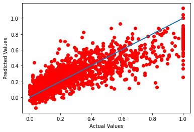

```python
# plot the correlation between the predicted and the actual values of the target attribute.
plt.plot(y_array, yHat, 'ro')
plt.plot([0,1,0],[0,1,0])
plt.xlabel('Actual Values')
plt.ylabel('Predicted Values')
plt.show()
```

```python
# Display the obtained regression coefficents
np.corrcoef(yHatT, y_array)
```

```
array([[1.        , 0.83360656],
       [0.83360656, 1.        ]])
```

```python
# Compute RMSE using 10-fold x-validation

linreg = LinearRegression()

n = 10

kf = KFold(n_splits=n)
kf.get_n_splits(x)

xval_err = 0

for train, test in kf.split(x_array):
    linreg.fit(x_array[train],y_array[train])
    p = linreg.predict(x_array[test])
    e = p-y_array[test]
    xval_err += np.sqrt(np.dot(e,e)/len(x_array[test]))

rmse_10cv = xval_err/n
print("Training RMSE: ", rmse)
print("Cross Validation RMSE: ", rmse_10cv)
```

```
Training RMSE:  [[0.12869119]]
Cross Validation RMSE:  0.13589812838131432
```

C) Feature Selection: use the scikit-learn regression model from sklearn.linear_model with a subset of features to perform linear regression. For feature selection, write a script or function that takes as input the training data, target variable; the model; and any other parameters you find necessary, and returns the optimal percentage of the most informative features to use. Your approach should use k-fold cross-validation on the training data (you can use k=5). You can use feature_selection.SelectPercentile to find the most informative variables. Show the list of most informative variables and their weights [Note: since this is regression not classification, you should use feature_selection.f_regression as scoring function rather than chi2). Next, plot the model's mean absolute error values on cross-validation relative to the percentage of selected features (See scikit-learn's metrics.mean_absolute_error). In order to use cross_validation.cross_val_score with regression you'll need to pass to it scoring='mean_absolute_error' as a parameter. [Hint: for an example of a similar feature selection process please review the class example notebook. Also, review scikit-learn documentation for feature selection.]

```python
# Building training and testing dataset
SEED = 33
x_train, x_test, y_train, y_test = train_test_split(x_array, y_array, test_size=0.2, random_state=SEED)
x_train
```

```
array([[0.05, 0.53, 0.31, ..., 0.11, 0.05, 1.  ],
       [0.  , 0.45, 0.41, ..., 0.15, 0.06, 1.  ],
       [0.  , 0.51, 0.02, ..., 0.05, 0.05, 1.  ],
       ...,
       [0.08, 0.3 , 0.19, ..., 0.17, 0.01, 1.  ],
       [0.03, 0.49, 0.52, ..., 0.19, 0.01, 1.  ],
       [0.  , 0.3 , 0.01, ..., 0.32, 0.05, 1.  ]])
```

```
1 0.5360894148437451
6 0.592040520824551
11 0.601778965892241
16 0.6065378596060684
21 0.6195686008901277
26 0.6320320122486176
31 0.6330843294415326
36 0.6357845215607437
41 0.6382949058981565
46 0.6338288116865249
51 0.634425811547601
56 0.6335660086465557
61 0.6320853766229274
66 0.6301008817789582
71 0.6292051021544142
76 0.6326255838067981
81 0.6320436664693485
86 0.6344189717173288
91 0.6386093350936421
96 0.6397159219375993
19
Optimal percentile of features:96

Optimal number of features:93
```

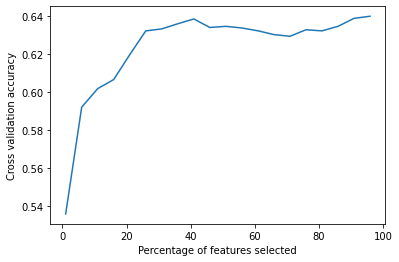

```python
import warnings
warnings.filterwarnings("ignore", category=RuntimeWarning)


linreg = LinearRegression()
percentiles = range(1, 100, 5)
results = []

for i in range(1, 100, 5):
    fs = SelectPercentile(feature_selection.f_regression, percentile=i)
    x_train_fs = fs.fit_transform(x_train, y_train)
    scores = cross_val_score(linreg, x_train_fs, y_train, cv=5)
    print (i,scores.mean())
    results = np.append(results, scores.mean())

optimal_percentile = np.where(results == results.max())[0]
print(optimal_percentile[0])
print ("Optimal percentile of features:{0}".format(percentiles[optimal_percentile[0]]), "\n")
optimal_num_features = int(percentiles[optimal_percentile[0]]*len(x.columns)/100)
print ("Optimal number of features:{0}".format(optimal_num_features), "\n")

# Plot percentile of features VS. cross-validation scores
import pylab as pl
pl.figure()
pl.xlabel("Percentage of features selected")
pl.ylabel("Cross validation accuracy")
pl.plot(percentiles,results)
```

```python
# List of the most informative variables and their weights

feats_scores = []

for i in range(len(x.columns.values)):
    if fs.get_support()[i]:
        t = (x.columns.values[i], fs.scores_[i])
        feats_scores.append(t)

feats_scores.sort(key=lambda x:x[1],reverse=True)
```

```python
for i in range(len(feats_scores)):
    print("{0}\t\t{1}\t\t{2}".format(i+1,feats_scores[i][0],feats_scores[i][1]))
```

```
1		PctKids2Par		1901.300150011694
2		PctIlleg		1856.8497011201284
3		PctFam2Par		1596.8391699129998
4		racePctWhite		1304.8806138268224
5		PctYoungKids2Par		1269.9824661860835
6		PctTeen2Par		1231.3207931534766
7		racepctblack		992.1643850847818
8		pctWPubAsst		783.2243592146204
9		pctWInvInc		761.0568397801972
10		FemalePctDiv		693.8626992089269
11		TotalPctDiv		677.2286585312045
12		PctPersOwnOccup		600.0985735147077
13		MalePctDivorce		580.3420144382145
14		PctPopUnderPov		569.4858535418621
15		PctUnemployed		532.3616336751962
16		PctVacantBoarded		489.3011943349635
17		PctHousNoPhone		485.84208180385934
18		PctNotHSGrad		461.0577920924555
19		PctHousOwnOcc		448.75871413842924
20		PctHousLess3BR		446.47828959213
21		NumIlleg		399.8278427791822
22		medFamInc		374.43469571111996
23		NumUnderPov		361.95940233900956
24		PctPersDenseHous		348.80809055762427
25		medIncome		341.30957351605116
26		HousVacant		314.7249171324904
27		PctLess9thGrade		296.03204170554983
28		NumInShelters		246.13471918201887
29		PctLargHouseFam		240.008616471101
30		MedNumBR		237.21372639671583
31		population		229.5994387214819
32		PctWOFullPlumb		229.04098088357475
33		numbUrban		223.61673819229597
34		perCapInc		214.96942659482886
35		PctEmploy		196.3843559733524
36		NumStreet		176.23838096673356
37		MedRentPctHousInc		173.16720421853947
38		pctWWage		170.55412925955056
39		PctBSorMore		169.04178961922028
40		PctHousOccup		167.39220992654202
```

[output cut: 39 more lines]

```
80		indianPerCap		15.657126482566786
81		agePct16t24		14.737467272122725
82		pctUrban		11.597086842327668
83		pctWRetire		11.191073676040737
84		PctEmplProfServ		9.095859408910066
85		PctSameCity85		8.974071819214346
86		PctBornSameState		8.14489420968292
87		agePct65up		7.74934075712134
88		agePct12t21		5.332362334669452
89		MedOwnCostPctIncNoMtg		4.1943822607824774
90		PersPerOccupHous		3.197458206754188
91		racePctAsian		3.1076289739671172
92		householdsize		2.927127326802512
93		MedOwnCostPctInc		1.7135044620197113
94		PctWorkMomYoungKids		1.5303938462644844
```

```python
# Calculate Mean absolute error on cross validation relative to the percentage of selected features.
fs = feature_selection.SelectPercentile(feature_selection.f_regression, percentile=96)
x_trainfs = fs.fit_transform(x_train, y_train)
scores = cross_val_score(linreg, x_train_fs, y_train, cv=5, scoring='neg_mean_absolute_error')
scores = [abs(i) for i in scores]

print("Mean Absolute Error: ", np.mean(scores))
```

```
Mean Absolute Error:  0.09740494162626856
```

D) Next, perform Ridge Regression and Lasso Regression using the modules from sklearn.linear_model. In each case, perform systematic model selection to identify the optimal alpha parameter. First, create a 20%-80% randomized split of the data. Set aside the test portion; the model selection process should be performed using the 80% training data partition. You should create a function that takes as input the data and target variable; the parameter to vary and a list of its values; the model to be trained; and any other relevant input needed to determine the optimal value for the specified parameter. The model selection process should perform k-fold cross validation (k should be a parameter, but you can select k=5 for this problem). You should also plot the error values on the training and cross-validation splits across the specified values of the alpha parameter. Finally, using the best alpha value, run the model on the set-aside test data. Discuss your observation and conclusions. [Hint: for an example of a similar model selection process please review the class example notebook.]

```python
# Creating 20-80 randomized split of the data
SEED = 33
x_train, x_test, y_train, y_test = train_test_split(x_array, y_array, test_size=0.2, random_state=SEED)
```

```python
def calc_params(X, y, clf, param_values, param_name, K):

    # Convert input to Numpy arrays
    X = np.array(X)
    y = np.array(y)

    # initialize training and testing score arrays with zeros
    train_scores = np.zeros(len(param_values))
    test_scores = np.zeros(len(param_values))

    # iterate over the different parameter values
    for i, param_value in enumerate(param_values):

        # set classifier parameters
        clf.set_params(**{param_name:param_value})

        # initialize the K scores obtained for each fold
        k_train_scores = np.zeros(K)
        k_test_scores = np.zeros(K)

        # create KFold cross validation
        cv = KFold(n_splits=K, shuffle=True, random_state=0)

        # iterate over the K folds

        for j, (train, test) in enumerate(cv.split(X)):
            # fit the classifier in the corresponding fold
            # and obtain the corresponding accuracy scores on train and test sets
            clf.fit(X[train], y[train])
            k_train_scores[j] = clf.score(X[train], y[train])
            k_test_scores[j] = clf.score(X[test], y[test])


        # store the mean of the K fold scores
        train_scores[i] = np.mean(k_train_scores)
        test_scores[i] = np.mean(k_test_scores)
        print('{}: {} \t\t\t training scores: {}'.format(param_name, param_value,train_scores[i]))

    # plot the training and testing scores in a log scale
    plt.plot(param_values, train_scores, label='Train', alpha=0.4, lw=2, c='b')
    plt.plot(param_values, test_scores, label='X-Val', alpha=0.4, lw=2, c='g')
    plt.legend(loc=7)
    plt.xlabel(param_name + " values")
    plt.ylabel("Mean cross validation accuracy")

    # return the training and testing scores on each parameter value
    return train_scores, test_scores
```

```
alpha: 0.001 			 training scores: 0.6964389091962628
alpha: 0.40914285714285714 			 training scores: 0.6922653863114144
alpha: 0.8172857142857143 			 training scores: 0.6894562776945415
alpha: 1.2254285714285713 			 training scores: 0.6872081536157817
alpha: 1.6335714285714285 			 training scores: 0.685323165764458
alpha: 2.0417142857142854 			 training scores: 0.683698135118035
alpha: 2.4498571428571427 			 training scores: 0.6822691792407158
alpha: 2.858 			 training scores: 0.6809935820056567
alpha: 3.266142857142857 			 training scores: 0.6798412921006347
alpha: 3.674285714285714 			 training scores: 0.6787903404631448
alpha: 4.082428571428571 			 training scores: 0.6778241666086664
alpha: 4.490571428571429 			 training scores: 0.6769299687630161
alpha: 4.898714285714286 			 training scores: 0.6760976400128806
alpha: 5.306857142857143 			 training scores: 0.6753190570362358
alpha: 5.715000000000001 			 training scores: 0.6745875897747355
alpha: 6.123142857142858 			 training scores: 0.6738977543981728
alpha: 6.531285714285715 			 training scores: 0.6732449619933519
alpha: 6.9394285714285715 			 training scores: 0.6726253328748963
alpha: 7.347571428571428 			 training scores: 0.6720355569189437
alpha: 7.755714285714286 			 training scores: 0.6714727868346707
alpha: 8.163857142857141 			 training scores: 0.6709345554397805
alpha: 8.572 			 training scores: 0.6704187107165761
alpha: 8.980142857142857 			 training scores: 0.6699233642340778
alpha: 9.388285714285713 			 training scores: 0.6694468497528592
alpha: 9.79642857142857 			 training scores: 0.6689876896824908
alpha: 10.204571428571429 			 training scores: 0.668544567662517
alpha: 10.612714285714285 			 training scores: 0.6681163059677042
alpha: 11.020857142857142 			 training scores: 0.6677018467499162
alpha: 11.429 			 training scores: 0.6673002363578207
alpha: 11.837142857142856 			 training scores: 0.6669106121456616
alpha: 12.245285714285714 			 training scores: 0.6665321913100745
alpha: 12.65342857142857 			 training scores: 0.6661642613908468
alpha: 13.061571428571428 			 training scores: 0.6658061721457991
alpha: 13.469714285714286 			 training scores: 0.6654573285673477
alpha: 13.877857142857142 			 training scores: 0.665117184853057
alpha: 14.286 			 training scores: 0.6647852391776045
alpha: 14.694142857142856 			 training scores: 0.6644610291413902
alpha: 15.102285714285713 			 training scores: 0.6641441277931589
alpha: 15.510428571428571 			 training scores: 0.663834140141752
alpha: 15.918571428571427 			 training scores: 0.6635307000864314
alpha: 16.326714285714285 			 training scores: 0.6632334677068322
alpha: 16.734857142857145 			 training scores: 0.6629421268630804
alpha: 17.143 			 training scores: 0.6626563830643839
alpha: 17.551142857142857 			 training scores: 0.6623759615708089
alpha: 17.959285714285716 			 training scores: 0.6621006056982566
alpha: 18.367428571428572 			 training scores: 0.6618300753010657
alpha: 18.77557142857143 			 training scores: 0.6615641454103469
alpha: 19.183714285714288 			 training scores: 0.6613026050092461
alpha: 19.591857142857144 			 training scores: 0.6610452559289307
alpha: 20.0 			 training scores: 0.6607919118512882
```

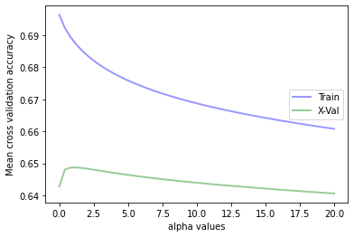

```python
# Ridge regression
alpha = np.linspace(.001,20,50)
ridge = Ridge(alpha=alpha)

train_scores, test_scores = calc_params(x_train, y_train, ridge, alpha, 'alpha', 5)
```

```python
# Need to get best value from both test and training scores
print(np.argmax(test_scores))
print(np.argmax(train_scores))
```

```
3
0
```

```python
# Create linear regression object with 2 because it is not too big to cause overfitting
ridge = Ridge(alpha=alpha[3])

# Train the model with the training set
ridge.fit(x_train, y_train)

# Computing RMSE on testing data
p = ridge.predict(x_test)
error = p - y_test
total_error = np.dot(error, error)
rmse = np.sqrt(total_error/len(p))

print(' Ridge Regression RMSE: {}'.format(rmse))
```

```
 Ridge Regression RMSE: 0.1363198066240668
```

```
alpha: 0.0001 			 training scores: 0.6865429330425068
alpha: 0.0009142857142857143 			 training scores: 0.6575210966068838
alpha: 0.0017285714285714285 			 training scores: 0.6463851941913227
alpha: 0.0025428571428571423 			 training scores: 0.6373482994703696
alpha: 0.0033571428571428567 			 training scores: 0.6283823509995646
alpha: 0.004171428571428572 			 training scores: 0.6189776804831746
alpha: 0.004985714285714285 			 training scores: 0.6087253362858884
alpha: 0.0058 			 training scores: 0.5992129394580459
alpha: 0.006614285714285714 			 training scores: 0.5903031904632707
alpha: 0.0074285714285714285 			 training scores: 0.5820836595569603
alpha: 0.008242857142857142 			 training scores: 0.5739670989881993
alpha: 0.009057142857142856 			 training scores: 0.5652970701461688
alpha: 0.00987142857142857 			 training scores: 0.5564053717469697
alpha: 0.010685714285714284 			 training scores: 0.5475210224417036
alpha: 0.011499999999999998 			 training scores: 0.5388862545119688
alpha: 0.012314285714285713 			 training scores: 0.5296178916900267
alpha: 0.013128571428571427 			 training scores: 0.5197153194662681
alpha: 0.01394285714285714 			 training scores: 0.5091794038137527
alpha: 0.014757142857142856 			 training scores: 0.4980096782925981
alpha: 0.01557142857142857 			 training scores: 0.486205784189581
alpha: 0.016385714285714285 			 training scores: 0.47376807091760353
alpha: 0.017199999999999997 			 training scores: 0.4606959891486827
alpha: 0.018014285714285712 			 training scores: 0.44699157837881087
alpha: 0.018828571428571427 			 training scores: 0.4326524133841603
alpha: 0.01964285714285714 			 training scores: 0.417678752871839
alpha: 0.020457142857142854 			 training scores: 0.4023113411789442
alpha: 0.02127142857142857 			 training scores: 0.38729588696176853
alpha: 0.022085714285714285 			 training scores: 0.3725043814167288
alpha: 0.022899999999999997 			 training scores: 0.358194775953891
alpha: 0.023714285714285712 			 training scores: 0.34351108997916774
alpha: 0.024528571428571427 			 training scores: 0.3283142315469146
alpha: 0.02534285714285714 			 training scores: 0.31260506619122447
alpha: 0.026157142857142855 			 training scores: 0.29638240057117116
alpha: 0.02697142857142857 			 training scores: 0.279646700113252
alpha: 0.02778571428571428 			 training scores: 0.2623979833726097
alpha: 0.028599999999999997 			 training scores: 0.2446366063039168
alpha: 0.029414285714285712 			 training scores: 0.22636217021550503
alpha: 0.030228571428571424 			 training scores: 0.20757439792948337
alpha: 0.03104285714285714 			 training scores: 0.18827360717641212
alpha: 0.031857142857142855 			 training scores: 0.16845980156602158
alpha: 0.032671428571428573 			 training scores: 0.1483174739826853
alpha: 0.033485714285714285 			 training scores: 0.12790601774056445
alpha: 0.0343 			 training scores: 0.10724956716268588
alpha: 0.035114285714285716 			 training scores: 0.0862049592660836
alpha: 0.03592857142857143 			 training scores: 0.06475924990676726
alpha: 0.03674285714285714 			 training scores: 0.043491481448525306
alpha: 0.03755714285714286 			 training scores: 0.026061286423654528
alpha: 0.03837142857142857 			 training scores: 0.009130994884341681
alpha: 0.03918571428571428 			 training scores: 0.0009729984076419562
alpha: 0.04 			 training scores: 0.0
```

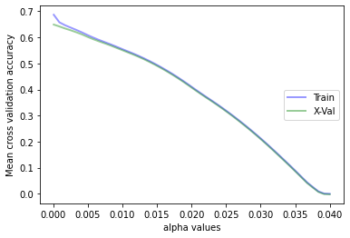

```python
# Lasso Regression
alpha = np.linspace(.0001, .04, 50)
lasso = Lasso(alpha=alpha)

train_scores, test_scores = calc_params(x_train, y_train, lasso, alpha, 'alpha', 5)
```

```python
# Need to get best value from both test and training scores
print(np.argmax(test_scores))
print(np.argmax(train_scores))
```

```
0
0
```

```python
# Since both values were 0 we choose 0 as the best value
lasso = Lasso(alpha=test_scores[0])

lasso.fit(x_train, y_train)

p = lasso.predict(x_test)
error = p - y_test
total_error = np.dot(error, error)
rmse = np.sqrt(total_error/len(p))

print('Lasso Regression RMSE: {}'.format(rmse))
```

```
Lasso Regression RMSE: 0.2456818133605803
```

When comparing linear, ridge, and lasso regression with each other, we the lowest value of 0.12869119 with Linear regression, then 0.1363198066240668 with ridge regression, and finally 0.2456818133605803 with lasso regression. Linear and ridge regression are very close to each other but linear regression is slightly better. In this case, we would want to use Linear regression over ridge regression because its RMSE value is smaller. We would also not want to use Lasso regression since its RMSE value is nearly double that of linear and ridge regression.

E) Next, perform regression using Stochastic Gradient Descent for regression. For this part, you should use the SGDRegessor module from sklearn.linear_model. Again, start by a creating randomized 80%-20% train-test split. SGDRegessor requires that features be standardized (with 0 mean and scaled by standard deviation). Prior to fiting the model, perform the scaling using StandardScaler from sklearn.preprocessing. For this problem, perform a grid search (using GridSearchCV from sklearn.grid_search) Your grid search should compare combinations of two penalty parameters ('l2', 'l1') and different values of alpha (alpha could vary from 0.0001 which is the default to relatively large values, say 10). Using the best parameters, apply the model to the set-aside test data. Finally, perform model selection (similar to part d, above) to find the best "l1_ratio" parameter using SGDRegressor with the "elasticnet" penalty parameter. [Note: "l1_ratio" is The Elastic Net mixing parameter, with 0 <= l1_ratio <= 1; l1_ratio=0 corresponds to L2 penalty, l1_ratio=1 to L1 penalty; defaults to 0.15.] Using the best mixing ratio, apply the Elastic Net model to the set-aside test data. Provide a summary of your findings from the above experiments.

```python
# Standardizing data
scaler = StandardScaler()
scaler.fit(x_array)
x_sgd = scaler.transform(x_array)
x_train, x_test, y_train, y_test = train_test_split(x_sgd, y_array, test_size=0.2, random_state=SEED)
```

```python
# Setting up Grid Search
sgdreg = SGDRegressor()

parameters = {
    'penalty': ['l2','l1'],
    'alpha': np.linspace(.0001, 1, 100),
}

gs = GridSearchCV(sgdreg, parameters, verbose=1, cv=5)
```

```python
# Running the grid search
gs.fit(x_train,y_train)
```

```
Fitting 5 folds for each of 200 candidates, totalling 1000 fits
```

```
GridSearchCV(cv=5, estimator=SGDRegressor(),
             param_grid={'alpha': array([1.000e-04, 1.020e-02, 2.030e-02, 3.040e-02, 4.050e-02, 5.060e-02,
       6.070e-02, 7.080e-02, 8.090e-02, 9.100e-02, 1.011e-01, 1.112e-01,
       1.213e-01, 1.314e-01, 1.415e-01, 1.516e-01, 1.617e-01, 1.718e-01,
       1.819e-01, 1.920e-01, 2.021e-01, 2.122e-01, 2.223e-01, 2.324e-01,
       2.425e-01, 2.526e-01, 2.627e-01, 2.728e-01,...
       6.667e-01, 6.768e-01, 6.869e-01, 6.970e-01, 7.071e-01, 7.172e-01,
       7.273e-01, 7.374e-01, 7.475e-01, 7.576e-01, 7.677e-01, 7.778e-01,
       7.879e-01, 7.980e-01, 8.081e-01, 8.182e-01, 8.283e-01, 8.384e-01,
       8.485e-01, 8.586e-01, 8.687e-01, 8.788e-01, 8.889e-01, 8.990e-01,
       9.091e-01, 9.192e-01, 9.293e-01, 9.394e-01, 9.495e-01, 9.596e-01,
       9.697e-01, 9.798e-01, 9.899e-01, 1.000e+00]),
                         'penalty': ['l2', 'l1']},
             verbose=1)
```

```python
# Best parameters and score
gs.best_params_, gs.best_score_
```

```
({'alpha': 0.21219999999999997, 'penalty': 'l2'}, 0.6397223508187374)
```

```python
# applying the model to the set-aside test data
best_params = gs.best_params_

sgdreg = SGDRegressor(penalty=best_params["penalty"], alpha=best_params["alpha"])
sgdreg.fit(x_train,y_train)

scaler.fit(x_test)
x_test_sgd = scaler.transform(x_test)

p = sgdreg.predict(x_test_sgd)
error = p - y_test
total_error = np.dot(error,error)
rmse = np.sqrt(total_error/len(p))
print("SGD RMSE: ",np.mean(rmse))
```

```
SGD RMSE:  0.1493123625546011
```

```
l1_ratio: 0.0 			 training scores: 0.664040617694354
l1_ratio: 0.010101010101010102 			 training scores: 0.6682513019255238
l1_ratio: 0.020202020202020204 			 training scores: 0.6728941348431347
l1_ratio: 0.030303030303030304 			 training scores: 0.6720374135792213
l1_ratio: 0.04040404040404041 			 training scores: 0.6752572551560044
l1_ratio: 0.05050505050505051 			 training scores: 0.6675028568807116
l1_ratio: 0.06060606060606061 			 training scores: 0.670863711278757
l1_ratio: 0.07070707070707072 			 training scores: 0.6723768615207499
l1_ratio: 0.08080808080808081 			 training scores: 0.667087287766586
l1_ratio: 0.09090909090909091 			 training scores: 0.6676915740548335
l1_ratio: 0.10101010101010102 			 training scores: 0.6707227073311481
l1_ratio: 0.11111111111111112 			 training scores: 0.67002334862678
l1_ratio: 0.12121212121212122 			 training scores: 0.6695313564227753
l1_ratio: 0.13131313131313133 			 training scores: 0.6670310421622216
l1_ratio: 0.14141414141414144 			 training scores: 0.6645464596407179
l1_ratio: 0.15151515151515152 			 training scores: 0.6685183850589029
l1_ratio: 0.16161616161616163 			 training scores: 0.6711421201731167
l1_ratio: 0.17171717171717174 			 training scores: 0.664630466589877
l1_ratio: 0.18181818181818182 			 training scores: 0.6690403312811636
l1_ratio: 0.19191919191919193 			 training scores: 0.6650681231503961
l1_ratio: 0.20202020202020204 			 training scores: 0.6669944727575582
l1_ratio: 0.21212121212121213 			 training scores: 0.6641229648671263
l1_ratio: 0.22222222222222224 			 training scores: 0.6562796389801677
l1_ratio: 0.23232323232323235 			 training scores: 0.6661941300618814
l1_ratio: 0.24242424242424243 			 training scores: 0.6663860420121531
l1_ratio: 0.25252525252525254 			 training scores: 0.6665585894004926
l1_ratio: 0.26262626262626265 			 training scores: 0.6650793308779598
l1_ratio: 0.27272727272727276 			 training scores: 0.6700108219385286
l1_ratio: 0.2828282828282829 			 training scores: 0.6702942297040442
l1_ratio: 0.29292929292929293 			 training scores: 0.6742422607775322
l1_ratio: 0.30303030303030304 			 training scores: 0.673473720398422
l1_ratio: 0.31313131313131315 			 training scores: 0.6676154215661014
l1_ratio: 0.32323232323232326 			 training scores: 0.6735262143886334
l1_ratio: 0.33333333333333337 			 training scores: 0.6693174759100928
l1_ratio: 0.3434343434343435 			 training scores: 0.6752175847772781
l1_ratio: 0.3535353535353536 			 training scores: 0.6647293933122431
l1_ratio: 0.36363636363636365 			 training scores: 0.6676962156446737
l1_ratio: 0.37373737373737376 			 training scores: 0.6591423940985239
l1_ratio: 0.38383838383838387 			 training scores: 0.6646415837393984
l1_ratio: 0.393939393939394 			 training scores: 0.6647983068983336
```

[output cut: 45 more lines]

```
l1_ratio: 0.8585858585858587 			 training scores: 0.668347795612506
l1_ratio: 0.8686868686868687 			 training scores: 0.6672949898128628
l1_ratio: 0.8787878787878789 			 training scores: 0.6686559905481372
l1_ratio: 0.888888888888889 			 training scores: 0.669028561032394
l1_ratio: 0.8989898989898991 			 training scores: 0.6663784553087827
l1_ratio: 0.9090909090909092 			 training scores: 0.6673434201079986
l1_ratio: 0.9191919191919192 			 training scores: 0.6738729608908349
l1_ratio: 0.9292929292929294 			 training scores: 0.6706091104136729
l1_ratio: 0.9393939393939394 			 training scores: 0.6567957595519779
l1_ratio: 0.9494949494949496 			 training scores: 0.6673728466683884
l1_ratio: 0.9595959595959597 			 training scores: 0.6744511091888956
l1_ratio: 0.9696969696969697 			 training scores: 0.6727579843165612
l1_ratio: 0.9797979797979799 			 training scores: 0.6715675817628666
l1_ratio: 0.98989898989899 			 training scores: 0.6730595480776228
l1_ratio: 1.0 			 training scores: 0.6677876784202366
```

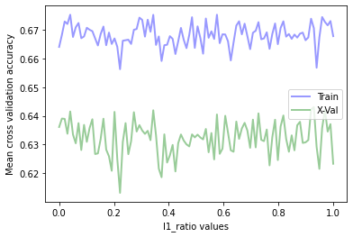

```python
# Model selection  with elasticnet penalty parameter
sgdreg = SGDRegressor(penalty='elasticnet')
l1_ratio = np.linspace(0, 1, 100)
train_scores, test_scores = calc_params(x_train, y_train, sgdreg, l1_ratio, 'l1_ratio', 5)
```

```python
# Getting best ratio and applying Elastic Net model to the set-aside test data
best_l1 = l1_ratio[np.argmax(test_scores)]
sgdreg = SGDRegressor(penalty="elasticnet", l1_ratio=best_l1)
sgdreg.fit(x_train, y_train)

scaler.fit(x_test)
x_test_sgd = scaler.transform(x_test)

p = sgdreg.predict(x_test_sgd)
error = p - y_test
total_error = np.dot(error,error)
rmse = np.sqrt(total_error/len(p))
print("SGD RMSE: ", rmse)
```

```
SGD RMSE:  0.13864335539327083
```

When comparing the experiements that we ran above, there is not much difference in the values that using elastic net as the penalty parameter yielded a lower score than when not using it. If we were only using the above two methods, we should use the elastic net penalty parameter since it yielded a lower score. However, if we were using all of the methods on this page including linear regression, lasso regression, and ridge regression, we would want to use linear regression because it has the lowest value for our data set.